# Analysis of Variance

b06208001 龔泓愷

2018年12月28日

## Q168

1. H0：The population means of four age groups are all the same.(mu1 = mu2 = mu3 = mu4)  
   H1：The population means of four age groups are not all equal.(mui != muj)
2. According to the output, the F-value is `7.41` and the p-value is `0.000`.  
   From the information, we can reject the null hypothesis in favor of the alternative hypothesis.  
   In other words, we can conclude that the population means of four age groups are not all equal.
3. According to the graph inside the output, we can notice that group1 (age 18-29) and group2 (age 60-89) probably hold the same opinions on the ideal number of children for a couple to have.  
   On the other hand, group2 (age 30-44) and group3 (age 45-59) thinks approximately the same on this issue and they do not overlap with group1 and group4.  
   Finally, we can see that the means of group1 and group4 are higher than group2 and group4.
4. According to column of `StDev` inside the output, we can see that the standard deviations of the four groups are roughly the same.  
   Since that, the assumption of equal population standard deviations is reasonable for these data.

## Q1624

1. xbar = 7；xbar1 = 5；xbar2= 6；xbar3 = 10

```r
drug <- c(rep('Drug1',4),rep('Drug2',4),rep('Drug3',4))
drug <- factor(drug)
count <- c(7,2,5,6,8,12,0,4,16,9,5,10)
data <- data.frame(drug, count)

xbar = mean(count);xbar
```

```
## [1] 7
```

```r
xbari = tapply(data$count, data$drug, mean);xbari
```

```
## Drug1 Drug2 Drug3
##     5     6    10
```

2. SS Groups = 56

```r
SSG = 0
for (i in 1:length(xbari)){
  SSG = SSG + 4 * (unname(xbari[i]) - xbar)^2
}
SSG
```

```
## [1] 56
```

3. SSTO = 212

```r
SSTO = 0
for (i in 1:length(count)){
  SSTO = SSTO + (count[i] - xbar)^2
}
SSTO
```

```
## [1] 212
```

4. SSE = 156

```r
SSE = SSTO - SSG;SSE
```

```
## [1] 156
```

5. F = 1.615；DF = 2 and 9.

```r
MSG = SSG/(3-1)
MSE = SSE/(12-3)
F_value = MSG/MSE;F_value
```

```
## [1] 1.615385
```

## Q1636

1. For male, those who sit in the front of the classroom slept the least the previous night.  
   On the other hand, those who sit in the back of the classroom slept the most.
2. For females, the situation reversed.  
   Those who sit in the back slept the least, and those sit in the front slept the most.
3. Yes, there is an interaction since there is no constant distance between the graph of female and male.  
   This shows us the preferred seat location in the classroom depends upon the sex of the student.

## Q1652

1. From the boxplot below, we can notice that the ratings of region 3 is the highest of all, region 2 is the lowest, and region 1 is somewhere between region 2 and 3.  
   We can also see that 3 regions have approximately the same spread, but the spread of region 3 is a little bit smaller than others.

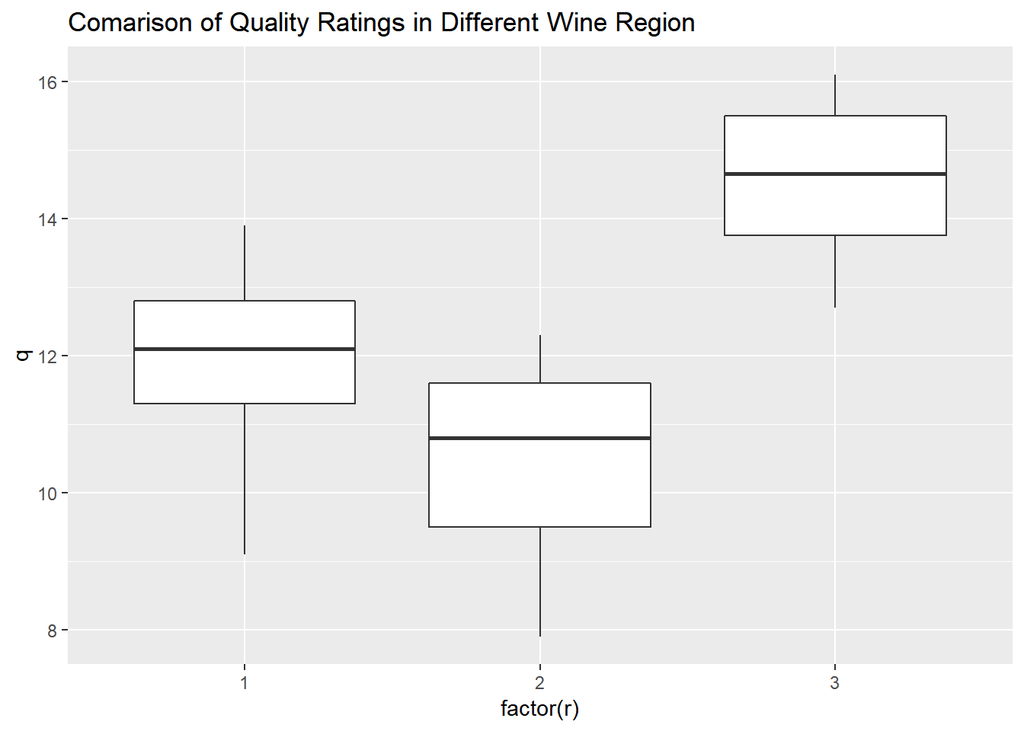

```r
load('wineratings.rdata')
library(ggplot2)
ggplot(wineratings, aes(x = factor(r), y = q)) +
  geom_boxplot() +
  ggtitle('Comarison of Quality Ratings in Different Wine Region')
```

2. xbar1 = 11.97647; xbar2 = 10.44444; xbar3 = 14.58333  
   sd1 = 1.327841; sd2 = 1.515017; sd3 = 1.111783

```r
library(dplyr)
group <- wineratings$q
group1 <- filter(wineratings, r == 1)$q
group2 <- filter(wineratings, r == 2)$q
group3 <- filter(wineratings, r == 3)$q
ni = c(17, 9, 12)
xbar = mean(group);xbar1 = mean(group1);xbar2 = mean(group2);xbar3 = mean(group3)
xbari = c(xbar1,xbar2, xbar3);xbari
```

```
## [1] 11.97647 10.44444 14.58333
```

```r
sd = sd(group);sd1 = sd(group1);sd2 = sd(group2);sd3 = sd(group3)
sdi = c(sd1, sd2, sd3);sdi
```

```
## [1] 1.327841 1.515017 1.111783
```

3. **Step1**  
   H0：The population means of 3 regions are all the same.(mu1 = mu2 = mu3)  
   H1：The population means of 3 regions are not all equal.(mui != muj)

**Step2**  
From the boxblot, we can see that all of 3 groups are symmetric and bell-shaped without extremely skewness and extreme outliers.  
Besides, the assumption of equal variance is reasonable since the spread of 3 groups is similar. Finally, we assumed that the samples are taken randomly and independently.  
Since that, the necessary conditions for conductiong an one-way ANOVA are all met.

Let’s calculate the f-statistic!

```r
#Degrees of feedom
NDF = 3 - 1; DDF = 38 - 3

#F-vlaue calculation
SSG = 0
for (i in 1:length(xbari)){
  SSG = SSG + ni[i] * (xbari[i] - xbar)^2
}
SSG
```

```
## [1] 94.61894
```

```r
SSTO = 0
for (i in 1:length(group)){
  SSTO = SSTO + (group[i] - xbar)^2
}
SSTO
```

```
## [1] 154.7884
```

```r
SSE = SSTO - SSG;SSE
```

```
## [1] 60.16948
```

```r
MSG = SSG/NDF
MSE = SSE/DDF
f_value = MSG/MSE;f_value
```

```
## [1] 27.51946
```

**Step3**

```r
p_value = pf(f_value, df1 = NDF, df2 = DDF, lower.tail = F);p_value
```

```
## [1] 6.586595e-08
```

**Step4**  
Since the p-value is smaller than the significance level we use (alpha = 0.5), we can now reject the null hypothesis in favor of the alternative hypothesis.

**Step5**  
The sample shows statistical significance which means we can conclude that the quality ratings in 3 different regions are not all the same.